# Size Ratios

## Examples

```r
# run default settings and show all output
myModel <- size_null_model(speciesData=dataRodents,suppressProg=TRUE)
summary(myModel)
```

```
## Time Stamp:  Sun Apr  5 23:14:15 2015
## Reproducible:  FALSE
## Number of Replications:  1000
## Elapsed Time:  0.13 secs
## Metric:  var_ratio
## Algorithm:  size_uniform
## Observed Index:  0.25135
## Mean Of Simulated Index:  3.5785
## Variance Of Simulated Index:  23.193
## Lower 95% (1-tail):  0.29999
## Upper 95% (1-tail):  13.658
## Lower 95% (2-tail):  0.20587
## Upper 95% (2-tail):  19.377
## Lower-tail P =  0.035
## Upper-tail P =  0.965
## Observed metric > 35 simulated metrics
## Observed metric < 965 simulated metrics
## Observed metric = 0 simulated metrics
## Standardized Effect Size (SES):  -0.69088
```

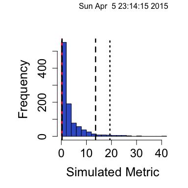

```r
plot(myModel,type = "hist")
```

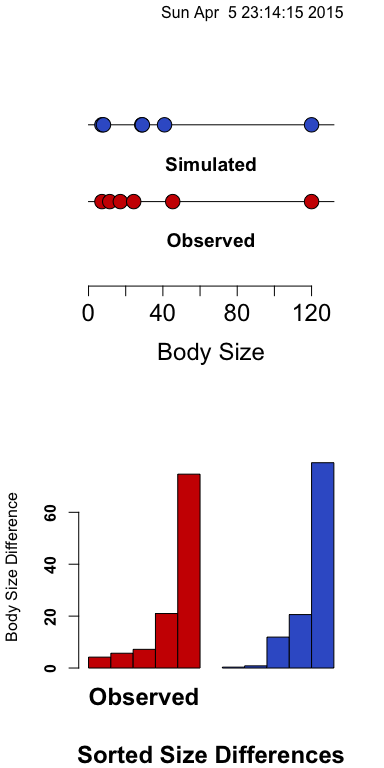

```r
plot(myModel,type="size") # throws error in vignette: figure margins too large
```

```r
# test for minimum size differences with a source pool model

# create a source pool of the rodent body sizes plus 20 other species
mySource <-c(dataRodents$Sonoran,as.double(sample(150,20)))

# create an arbitrary set of probabilty weights
myProbs <- runif(26)

# run the model
myModel <- size_null_model(speciesData=dataRodents,suppressProg=TRUE,
           metric="min_diff",algo="size_source_pool",
           algoOpts=list(sourcePool=mySource,speciesProbs=myProbs))

# show the results
summary(myModel)
```

```
## Time Stamp:  Sun Apr  5 23:14:15 2015
## Reproducible:  FALSE
## Number of Replications:  1000
## Elapsed Time:  0.1 secs
## Metric:  min_diff
## Algorithm:  size_source_pool
## Observed Index:  4.2
## Mean Of Simulated Index:  3.5292
## Variance Of Simulated Index:  10.226
## Lower 95% (1-tail):  0.4
## Upper 95% (1-tail):  10
## Lower 95% (2-tail):  0.4
## Upper 95% (2-tail):  11.802
## Lower-tail P =  0.708
## Upper-tail P =  0.348
## Observed metric > 652 simulated metrics
## Observed metric < 292 simulated metrics
## Observed metric = 56 simulated metrics
## Standardized Effect Size (SES):  0.20977
```

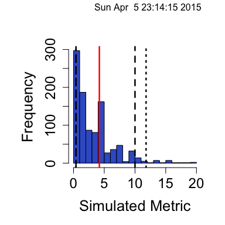

```r
plot(myModel,type="hist")
```

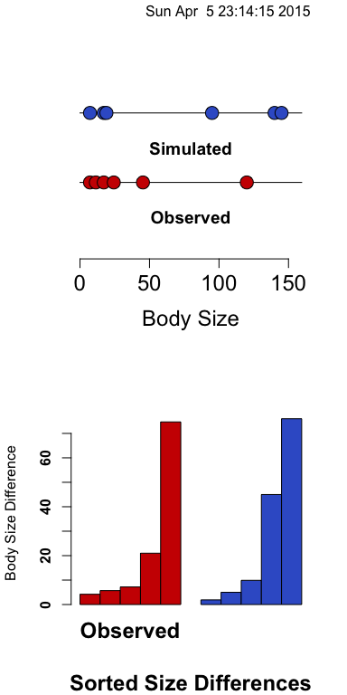

```r
plot(myModel,type="size")
```

## Caveats

These models carry the usual restrictions on the analysis of body size patterns as they relate to competition and resource use: 1) body size or morphology are related to resource use; 2) the underlying resource spectrum is symmetric; 3) competition occurs primarily among adult organisms; 4) sexual size dimorphism and intraspecific variation in body size are ignored; 5) abundances of all species are approximately equal (Gotelli and Graves 1996). These models also treat each species as an independent data point and do not explicitly incorporate effects of phylogenetic inertia (Losos 1990).

## Literature

Brown, J.H. 1975. Geographical ecology of desert rodents. p. 314-341 in: Ecology and Evolution of Communities. M.L. Cody and J.M. Diamond (eds.). Harvard University Press, Cambridge.

Brown, J.H. 1998. The desert granivory experiments at Portal. Pages 71-95 in W.J. Resetarits, Jr. and J. Bernardo, eds. Experimental ecology: issues and perspectives. Oxford University Press, New York.

Brown, J.H., D.W. Davidson, J.C. Munger, and R.S. Inouye. 1986. Experimental community ecology: the desert granivore system. Pages 41-61 in J. Diamond and T. J. Case, eds. Community ecology. Harper and Row, New York.

Gotelli, N.J. and G.R. Graves. 1996. Null models in ecology. Smithsonian Institution Press, Washington DC.

Graves, G.R. and N.J. Gotelli. 1983. Neotropical land-bridge avifaunas: new approaches to null hypotheses in biogeography. Oikos 41: 322-333.

Hutchinson, G.E. 1959. Homage to Santa Rosalia or why are there so many kinds of animals? The American Naturalist 93: 145-159.

Losos, J.B. 1990. A phylogenetic analysis of character displacement in Caribbean Anolis lizards. Evolution 44: 558-569.

Poole R.W. and B.J. Rathcke. 1979. Regularity, randomness, and aggregation in flowering phenologies. Science 203: 470-471.

Simberloff, D., and W. Boecklen. 1981. Santa Rosalia reconsidered: size ratios and competition. Evolution 35: 1206-1228.

Tonkyn, D.W., and B.J. Cole. 1986. The statistical analysis of size ratios. The American Naturalist 128: 66-81.